# POC2 potential counties

Below is a map of counties the intersect or are adjacent to intersected counties that we are considering evaluating as part of POC2. I’ve organized the counties into 3 tiers each with 2 groups. Tier 1 is our primary focus; Tier 2 is our secondary focus; Tier 3 is are stretch goal. In each Tier, group `_1` contains counties that intersect the WCS priority landscapes, group `_2` contains counties that are adjacent to those counties.

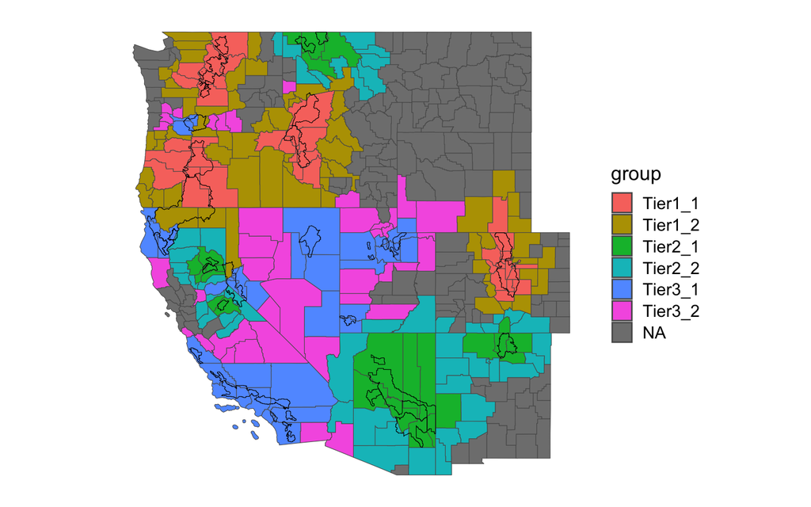

Below is the list of counties intersecting (n=38) or adjacent (n=64) to the 4 priority landscapes which are the primary focus of the POC2.

```
##
## Tier1_1 Tier1_2
##      38      64
```

| geoid | name2 | state | group |
| --- | --- | --- | --- |
| 08005 | Arapahoe County | CO | Tier1_1 |
| 08013 | Boulder County | CO | Tier1_1 |
| 08019 | Clear Creek County | CO | Tier1_1 |
| 08031 | Denver County | CO | Tier1_1 |
| 08035 | Douglas County | CO | Tier1_1 |
| 08041 | El Paso County | CO | Tier1_1 |
| 08043 | Fremont County | CO | Tier1_1 |
| 08047 | Gilpin County | CO | Tier1_1 |
| 08049 | Grand County | CO | Tier1_1 |
| 08059 | Jefferson County | CO | Tier1_1 |
| 08069 | Larimer County | CO | Tier1_1 |
| 08093 | Park County | CO | Tier1_1 |
| 08117 | Summit County | CO | Tier1_1 |
| 08119 | Teller County | CO | Tier1_1 |
| 16001 | Ada County | ID | Tier1_1 |
| 16003 | Adams County | ID | Tier1_1 |
| 16015 | Boise County | ID | Tier1_1 |
| 16039 | Elmore County | ID | Tier1_1 |
| 16045 | Gem County | ID | Tier1_1 |
| 16049 | Idaho County | ID | Tier1_1 |
| 16085 | Valley County | ID | Tier1_1 |
| 16087 | Washington County | ID | Tier1_1 |
| 41001 | Baker County | OR | Tier1_1 |
| 41017 | Deschutes County | OR | Tier1_1 |
| 41019 | Douglas County | OR | Tier1_1 |
| 41031 | Jefferson County | OR | Tier1_1 |
| 41035 | Klamath County | OR | Tier1_1 |
| 41037 | Lake County | OR | Tier1_1 |
| 41039 | Lane County | OR | Tier1_1 |
| 41043 | Linn County | OR | Tier1_1 |

[output cut: 72 more lines]

Next is the list of counties intersecting (n=24) or adjacent (n=51) to the 6 additional priority landscapes identified in the roll out of the Wildfire Crisis Strategy (WCS).

```
##
## Tier2_1 Tier2_2
##      24      51
```

| geoid | name2 | state | group |
| --- | --- | --- | --- |
| 04001 | Apache County | AZ | Tier2_1 |
| 04005 | Coconino County | AZ | Tier2_1 |
| 04007 | Gila County | AZ | Tier2_1 |
| 04009 | Graham County | AZ | Tier2_1 |
| 04011 | Greenlee County | AZ | Tier2_1 |
| 04017 | Navajo County | AZ | Tier2_1 |
| 04025 | Yavapai County | AZ | Tier2_1 |
| 06007 | Butte County | CA | Tier2_1 |
| 06009 | Calaveras County | CA | Tier2_1 |
| 06057 | Nevada County | CA | Tier2_1 |
| 06063 | Plumas County | CA | Tier2_1 |
| 06091 | Sierra County | CA | Tier2_1 |
| 06109 | Tuolumne County | CA | Tier2_1 |
| 06115 | Yuba County | CA | Tier2_1 |
| 08023 | Costilla County | CO | Tier2_1 |
| 16021 | Boundary County | ID | Tier2_1 |
| 30029 | Flathead County | MT | Tier2_1 |
| 30053 | Lincoln County | MT | Tier2_1 |
| 30089 | Sanders County | MT | Tier2_1 |
| 35003 | Catron County | NM | Tier2_1 |
| 35007 | Colfax County | NM | Tier2_1 |
| 35033 | Mora County | NM | Tier2_1 |
| 35039 | Rio Arriba County | NM | Tier2_1 |
| 35055 | Taos County | NM | Tier2_1 |
| 04003 | Cochise County | AZ | Tier2_2 |
| 04012 | La Paz County | AZ | Tier2_2 |
| 04013 | Maricopa County | AZ | Tier2_2 |
| 04015 | Mohave County | AZ | Tier2_2 |
| 04019 | Pima County | AZ | Tier2_2 |
| 04021 | Pinal County | AZ | Tier2_2 |
| 06003 | Alpine County | CA | Tier2_2 |
| 06005 | Amador County | CA | Tier2_2 |
| 06011 | Colusa County | CA | Tier2_2 |
| 06021 | Glenn County | CA | Tier2_2 |
| 06035 | Lassen County | CA | Tier2_2 |
| 06039 | Madera County | CA | Tier2_2 |
| 06043 | Mariposa County | CA | Tier2_2 |
| 06051 | Mono County | CA | Tier2_2 |
| 06061 | Placer County | CA | Tier2_2 |
| 06077 | San Joaquin County | CA | Tier2_2 |
| 06089 | Shasta County | CA | Tier2_2 |
| 06099 | Stanislaus County | CA | Tier2_2 |
| 06101 | Sutter County | CA | Tier2_2 |
| 06103 | Tehama County | CA | Tier2_2 |
| 08003 | Alamosa County | CO | Tier2_2 |
| 08007 | Archuleta County | CO | Tier2_2 |
| 08021 | Conejos County | CO | Tier2_2 |
| 08055 | Huerfano County | CO | Tier2_2 |
| 08071 | Las Animas County | CO | Tier2_2 |
| 08083 | Montezuma County | CO | Tier2_2 |
| 16017 | Bonner County | ID | Tier2_2 |
| 16079 | Shoshone County | ID | Tier2_2 |
| 30035 | Glacier County | MT | Tier2_2 |
| 30047 | Lake County | MT | Tier2_2 |
| 30049 | Lewis and Clark County | MT | Tier2_2 |
| 30061 | Mineral County | MT | Tier2_2 |
| 30073 | Pondera County | MT | Tier2_2 |
| 30077 | Powell County | MT | Tier2_2 |
| 30099 | Teton County | MT | Tier2_2 |
| 35006 | Cibola County | NM | Tier2_2 |
| 35017 | Grant County | NM | Tier2_2 |
| 35021 | Harding County | NM | Tier2_2 |
| 35023 | Hidalgo County | NM | Tier2_2 |
| 35028 | Los Alamos County | NM | Tier2_2 |
| 35031 | McKinley County | NM | Tier2_2 |
| 35043 | Sandoval County | NM | Tier2_2 |
| 35045 | San Juan County | NM | Tier2_2 |
| 35047 | San Miguel County | NM | Tier2_2 |
| 35049 | Santa Fe County | NM | Tier2_2 |
| 35051 | Sierra County | NM | Tier2_2 |
| 35053 | Socorro County | NM | Tier2_2 |
| 35059 | Union County | NM | Tier2_2 |
| 49025 | Kane County | UT | Tier2_2 |
| 49037 | San Juan County | UT | Tier2_2 |
| 53051 | Pend Oreille County | WA | Tier2_2 |

Finally, here is the list of counties intersecting (n=36) or adjacent (n=40) to the 11 priority landscapes identified in phase 2 of the WCS.

```
##
## Tier3_1 Tier3_2
##      36      40
```

| geoid | name2 | state | group |
| --- | --- | --- | --- |
| 06015 | Del Norte County | CA | Tier3_1 |
| 06017 | El Dorado County | CA | Tier3_1 |
| 06023 | Humboldt County | CA | Tier3_1 |
| 06029 | Kern County | CA | Tier3_1 |
| 06037 | Los Angeles County | CA | Tier3_1 |
| 06053 | Monterey County | CA | Tier3_1 |
| 06059 | Orange County | CA | Tier3_1 |
| 06065 | Riverside County | CA | Tier3_1 |
| 06071 | San Bernardino County | CA | Tier3_1 |
| 06073 | San Diego County | CA | Tier3_1 |
| 06079 | San Luis Obispo County | CA | Tier3_1 |
| 06083 | Santa Barbara County | CA | Tier3_1 |
| 06105 | Trinity County | CA | Tier3_1 |
| 06111 | Ventura County | CA | Tier3_1 |
| 32005 | Douglas County | NV | Tier3_1 |
| 32007 | Elko County | NV | Tier3_1 |
| 32011 | Eureka County | NV | Tier3_1 |
| 32017 | Lincoln County | NV | Tier3_1 |
| 32019 | Lyon County | NV | Tier3_1 |
| 32021 | Mineral County | NV | Tier3_1 |
| 32029 | Storey County | NV | Tier3_1 |
| 32033 | White Pine County | NV | Tier3_1 |
| 32510 | Carson City | NV | Tier3_1 |
| 41005 | Clackamas County | OR | Tier3_1 |
| 41027 | Hood River County | OR | Tier3_1 |
| 41051 | Multnomah County | OR | Tier3_1 |
| 49013 | Duchesne County | UT | Tier3_1 |
| 49021 | Iron County | UT | Tier3_1 |
| 49023 | Juab County | UT | Tier3_1 |
| 49035 | Salt Lake County | UT | Tier3_1 |
| 49043 | Summit County | UT | Tier3_1 |
| 49045 | Tooele County | UT | Tier3_1 |
| 49049 | Utah County | UT | Tier3_1 |
| 49051 | Wasatch County | UT | Tier3_1 |
| 49053 | Washington County | UT | Tier3_1 |
| 56041 | Uinta County | WY | Tier3_1 |
| 04027 | Yuma County | AZ | Tier3_2 |
| 06019 | Fresno County | CA | Tier3_2 |
| 06025 | Imperial County | CA | Tier3_2 |
| 06027 | Inyo County | CA | Tier3_2 |
| 06031 | Kings County | CA | Tier3_2 |
| 06045 | Mendocino County | CA | Tier3_2 |
| 06067 | Sacramento County | CA | Tier3_2 |
| 06069 | San Benito County | CA | Tier3_2 |
| 06087 | Santa Cruz County | CA | Tier3_2 |
| 06107 | Tulare County | CA | Tier3_2 |
| 16031 | Cassia County | ID | Tier3_2 |
| 16057 | Latah County | ID | Tier3_2 |
| 32001 | Churchill County | NV | Tier3_2 |
| 32003 | Clark County | NV | Tier3_2 |
| 32009 | Esmeralda County | NV | Tier3_2 |
| 32013 | Humboldt County | NV | Tier3_2 |
| 32015 | Lander County | NV | Tier3_2 |
| 32023 | Nye County | NV | Tier3_2 |
| 32027 | Pershing County | NV | Tier3_2 |
| 41009 | Columbia County | OR | Tier3_2 |
| 41021 | Gilliam County | OR | Tier3_2 |
| 41049 | Morrow County | OR | Tier3_2 |
| 41055 | Sherman County | OR | Tier3_2 |
| 41067 | Washington County | OR | Tier3_2 |
| 41071 | Yamhill County | OR | Tier3_2 |
| 49001 | Beaver County | UT | Tier3_2 |
| 49003 | Box Elder County | UT | Tier3_2 |
| 49007 | Carbon County | UT | Tier3_2 |
| 49009 | Daggett County | UT | Tier3_2 |
| 49011 | Davis County | UT | Tier3_2 |
| 49017 | Garfield County | UT | Tier3_2 |
| 49027 | Millard County | UT | Tier3_2 |
| 49029 | Morgan County | UT | Tier3_2 |
| 49033 | Rich County | UT | Tier3_2 |
| 49039 | Sanpete County | UT | Tier3_2 |
| 49047 | Uintah County | UT | Tier3_2 |
| 49057 | Weber County | UT | Tier3_2 |
| 53011 | Clark County | WA | Tier3_2 |
| 56023 | Lincoln County | WY | Tier3_2 |
| 56037 | Sweetwater County | WY | Tier3_2 |